# Chapter 1: Generative Models for Discrete Data

**Table of contents**

[1] Intro  
[2] Chapter 1: Generative Models for Discrete Data  
[2.1] Chapter Summary  
[2.2] Example  
[2.3] Discrete Probability Models  
[2.4] Multinomial distributions  
[2.5] Excercises  
[X] Misc.

**Intro**<sup>Return</sup>

- Book literally states, “The book will often throw readers into the pool and hope they can swim in spite of so many missing details.”
  - Book also states, “We assume no prior training in statistics.”
- This book is based upon R language + Bioconductor package
- Heterogenous data = many dimensions to biological data (ex) incubation time, temperature, condition)

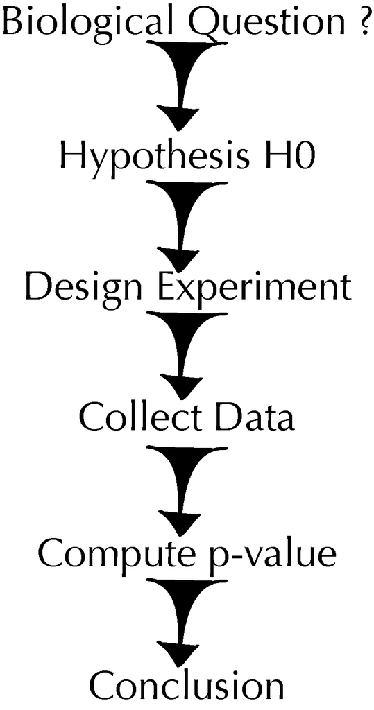

- **Exploratory data analysis** = Data used for statistical anlysis to summarize -> ex) simple plotting
  - **Confirmatory data analyses** = robust inferrence which don’t need assumptions for a conclusion -> ex) hypothesis testing, regression analysis, and variance analysis
- Large number of columns/features (p), small sample size/rows (n) problem
  - To predict an outcome from high #features, model parameters have to be magnitues higher than samples
  - Solution = use sparsity
    - Use parameters of ~0
    - Emperical Bayes = Don’t need to know parameters associated w/ each feature, just infer some/all features/groups share similar/same parammters
  - Bottom up approach to statistics = what model explains the data best? (work backwards)

    ◆ CH1 (Generative models - building blocks to draw conclusion of data)  
    ◆ CH2 (Choose model to explain data)  
    ◆ CH3 (Visualization)  
    ◆ CH4 (Mixture modeling)  
    ◆ CH5 (Clustering - distance reliance)  
    ◆ CH6 (Hypothesis test workflow)  
    ◆ CH7 (PCA + multivariate), CH8 (variance analysis (ANOVA))  
    ◆ CH9 (combination of data types), CH10 (networks + trees)  
    ◆ CH11 (feature extraction from images + spatial stats)  
    ◆ CH12 (traing algorithm - machine learning)  
    ◆ CH13 (experimental design)

**Chapter 1: Generative Models for Discrete Data**<sup>Return</sup>

- Counting events (ex) #codons, #reads, #GC to calculate %GC)
  - Counts = discrete variables
    - **Discrete variables** = countable variable up to a **limit** (ex) money)
  - Quantities (mass/intensity) = continous variables
    - **Continous variables** = if counted it could be **limitless** (ex) age of universe may be endless)
      - Age can be discrete if unit is specified (ex) months, or years)
      - Therefore, continous variables may be discrete under certain circumstances (ex) time on clock)
- Studies usually constricted by rules -> can predict probability of outcome == **Top-down approach of deduction**
  - Prior knowledge manipulates probabilities
- Parametric vs non-parametic data
  - **Parametric** = modelling w/ known facts(paramteters) about population
    - ex) normal distribution (parameters = mean(μ) and standard deviation(σ))
      - where mean = 0, and stdev = 1 in normal distribution
    - Should be used over nonparametric if applicable (more accurate, more statistical power = find true significance)
  - **Nonparametric(distribution-free)** = No assumptions about distribution, usually assumes distribution is not normally distributed
    - Less accurate vs parametric tests

**Chapter Summary**<sup>Return</sup>

- Calculating probabilities of **discrete events**
  - Model for basic distributions
    - **Bernoulli distribution** = represent single binary trial (ex) coin flip), as 0 and 1
      - *p* (probability of success) == 1
    - **Binomial distribution** = used for 1’s in *n* binary trial, create probabilities of *k* success (via R dbinom)
      - Can stimulate *n* trial binomial (via R rbinom)
    - **Poisson distribution** = used when *p* is small (rare 1’s - success)
      - One parameter *λ*
        - Poisson formula λ=np -> approximately same as binomial distribution (n,p) IF *p* is small
      - model #randomly occuring false +ves in assay (epitopes in sequence) -> assumed pre-positon false +ve rate *p* is small
      - Parametric model to find proabilities of extreme events (requires parameters - parametric)
    - **Multinomial distribution** = used for discrete events w/ >2 possible outcomes(levels)
      - Monte Carlo stimulations can help decide how much data is needed to test w/ multinomial model w/ equal probabilities and see if consistent w/ data
      - Probabilistic models to evaluate hypotheses of how data was generated
        - Assumptions of generative models
      - **Probability of seeing data w/ given hypothesis == p-value**

**Example**<sup>Return</sup>

- ex) Mutations along HIV genome occur at random rate of 5x10<sup>-4</sup>mutations/nt/rep cycle
  - If rep cycle = 1, then mutations in genome is about 10<sup>4</sup> = 10,000
    - (0.0005mutations*rep cycle/1nt) = (x mutations*1 cycle/10000 nt)
      - (0.0005mutations*rep cycle/1nt) * (10000 nt/1 cycle) = (x mutations)
      - (0.0005mutations * 10000 nt/1nt) = x mutations
      - 5 mutations = x
  - Poisson Distribution
    - of rate 5 mutations
    - This model can be used to predict #of mutations in one replication cycle (predicts ~5)
      - Variability of this estimate is √5 (standard error)

$$\begin{equation*}
P(X=k)= \frac{\lambda^k\;e^{-\lambda}}{k!}.
\end{equation*}$$

- **Poisson Formula, where λ=μ**
  - Probability of seeing *x* value
  - good model for rare events (ex) mutations)
  - Explained in “Discrete Probability Models” below

Therefore, chance of seeing 3 mutations is ~14%

`r`r # To find probability of x=0 to 12 mutations n=0:12 x = dpois(x=n, lambda=5) x

**Discrete Probability Models**<sup>Return</sup>

- Point mutations in binary = occurance(1 or yes) or nonoccurance(0 or no)
  - Yes/No = **levels** of categorical variable
    - **Categorical Variable** = variables that can be categorized into levels (ex) toothpaste brands)
  - Some events are nonbinary (ex) genotypes of diploid -> 3 levels AA, Aa, aa)
  - **To measure categorical variables of sample**
    - **Tally frequencies @each level as counts**
      - R categorical variables = factors
      - R automatically detects levels when making factors

`r`r #ex) Blood genotypes for n=19 people # Insert vector of data, then use table to categorize + count frequencies of levels

`r`r # To access levels of a R factor (category) genotype1=factor(genotype) #turn genotype vector into a factor levels(genotype1) #pull out the levels of the factor

- If making factor w/ levels not in data
  - If order of datapoints independent, then the random variable == exchangeable
  - Information of factor is summarized via counts(frequencies) in each level
    - The vector frequencies sufficient to capture all relevant info in data
- **Bernoulli Distribution**
  - ex) Tossing a coin results in 2 possible outcomes (simple experiment - single trial)
    - for this example, use `rbinom` (where r is for random, binom is for binomial).
      - rbinom [(Useful video)](https://www.youtube.com/watch?v=CM7ncRGlViE)
        - n = number of replicates of experiment **(Number of times a trial is performed)**
        - size = #of trials in each replicate **(Number of actions performed per trial)**

`r`r # ex) 15 fair coin tosses (Bernoulli trial) w/ probability of success (*p*) = 0.5 -> flip coin once (size=1) #rbinom = random generation of success/failure rbinom(n=15, prob=0.5, size=1)

Parameters/Arguements = subset of functions within a function  
◆ n=15 is parameter 1 (#trials to observe (replicates))  
◆ prob is parameter 2 (probability of success)  
◆ size is parameter 3 (means each individual replicate has *one* (trial) coin toss)

**Note** The answer using binomial equation always changes because two levels (success or failure)  
◆ outcome differs per run due to probability

Success and failure can have unequal probailities in Bernoulli distribution  
◆ But the probabilities must sum = 1 (complementary)

`r`r # ex) for 12 throws(trial replicates) of 1 ball into 2 boxes (one throw per replicate (size=1)) # Probability left = 1/3, right = 2/3

rbinom(n=12, prob=2/3, size=1)

Where 1 = successfully landed in right box, 0 = landed in left box

- **Binomial Distribution**

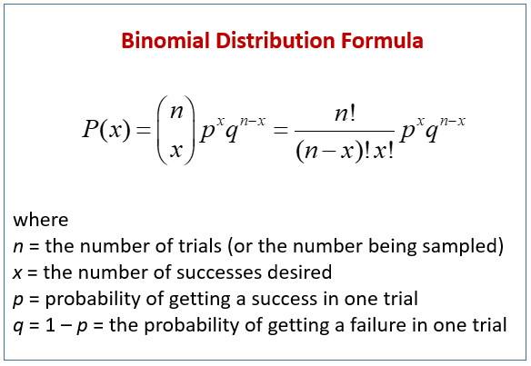

  - x is often denoted k
  - q = 1-p
  - B(n=20, p=1/6) want to know Prob(X=3) —— [3 success]
    - `dbinom(x=3, size=20, p=1/6)`
      - Formula corresponding to above figure
      - size = n
      - x = k
      - p = p

> The number of trials is the number we input in R as the size parameter and is often written n, while the probability of success is p. Mathematical theory tells us that for X distributed as a binomial distribution with parameters (n, p) written X∼B(n,p), the probability of seeing X = k successes is

$$\begin{equation*}
\begin{aligned}
P(X=k) = \frac{n\times (n-1)... (n-k+1)}{k\times(k-1)... 1}\; p^k\, (1-p)^{n-k} \\
= \frac{n!}{(n-k)!k!}\;p^k\, (1-p)^{n-k}\\
= { n \choose k}\; p^k\, (1-p)^{n-k}.\end{aligned}
\end{equation*}$$

- **Bernoulli vs Binomial**
  - 2 outcomes (success/fail)
    - size (action per trial) = 1 Bernouli (One action per multiple Bernoulli trials)
    - size (action per trial) = >=1 then binomial (Many actions per one Bernoulli trial = sum)

[Source](https://math.stackexchange.com/questions/838107/what-is-the-difference-and-relationship-between-the-binomial-and-bernoulli-distr/838122)  
◆ Bernoulli random variable has two possible outcomes: 0 or 1. A binomial distribution is the sum of independent and identically distributed Bernoulli random variables.  
◆ In general, if there are n Bernoulli trials, then the sum of those trials is binomially distributed with parameters n and p.  
◆ Note that a binomial random variable with parameter n=1 is equivalent to a Bernoulli random variable, i.e. there is only one trial.

- ex) Only care about #balls go into right box & #throws doesn’t matter (independence)
  - sum cells in output vector of Bernoulli
  - Instead of using a binary vector, as in Bernoulli Distribution, the output is a single number (because sum)

Two level model for two possible outcomes (ex) h/t, success/fail, yes/no, CpG/non-CpG, M/F, **diseased/healthy**)  
◆ Probability *p* of success or complementary event failure (1-p) -> only for independent events (exchangeable)  
◆ ex) in n=15, if SSSSSFSSSSFFFSF, then #success=10, fail=5 -> n15, x=10

`r`r # 1 Bernoulli trial filp a coin 15 times w/ success probability of 0.3 == binomial form variable B(15, 0.3) -> B(n,p) # Set seed is a state where random numbers are always the same for that seed (so that results can be replicated if same seed used) -> useful for binomial results b/c success/fail probabilities variable set.seed(235569515) rbinom(n=1, prob = 0.3, size = 15) # Binomial form (sum of 15 Bernoulli trials)

`r`r #Q) What is the most common outcome number after 0 to 15 Bernoulli trials? # Check probability mass distribution

#0 to 15 trials, filp coin 15 times per trial, success probability of heads is 0.3 prob <- dbinom(0:15, prob=0.3, size=15) round(prob, 2)

`r`r #Visualize previous question with a barplot # names.arg = vector names to be plotted under each bar barplot(prob, names.arg=0:15, col=)

`r`r #Q) output of the formula for k=3, p=2/3, n=4? B(4,2/3) # per 1 Bernoulli trial # n = flip a coin 4 times in 1 trial (size) # p = probability of heads is 2/3 # k = expected success (heads) of 3 # dbinom will find success rate of 3 heads when flipped 4 times in one trial dbinom(x=3, prob=2/3, size=4)

- Poisson Distribution

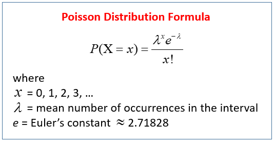

  - **Used when small probability of success (*p*) with large #of trials (*n*)**
    - Can use in place of binomial distribution B(n,p) - reason = Poisson is simpler to calculate
  - Poisson rate parameter λ=np

`r`r # Q) Probability of mass distribution # Observe 0 to 12 mutation in genome, where n= 10^4 nucleotides, and probability of mutations is p=5x10^-4 per nt

x = 0:12

#Binomial B(n,p) dbinom(x, prob=0.0005, size=10000)

#Poisson (Î»=np) dpois(x, lambda=((10000*0.0005)))

Very similar output, binomial depends on 2 parameters (n,p) while poisson is a product of n*p

`r`r # Another example using poisson formula and not the function (Î»=5 and P(X=3)) (5^3 * exp(-5))/factorial(3) #same as dpois(x=3, lambda=5)

`r`r # Stimulate 300,000 mutation process (Bernoulli trials/generations) on 10,000nt sequence (size) # Mutation rate 5x10^-4 (probability)

rbinom(1, prob=5e-4, size=10000) stimulation = rbinom(n=300000, prob=5e-4, size=10000) barplot(table(stimulation), col=)

- Example of using distributions: Epitope detecion
  - Testing pharmaceuticals requires finding proteins that provoke unwated reactions (molecular sites of protein = epitopes)
  - ELISA assay error model
    - Known parameters
      - False positive rate/baseline noise level per position = 0.01 (*p*)
        - P(declare epitope | no epitope) -> Probability of declaring a hit, we think we have an epitope, when there is none
          - The vertical bar in expressions means “X happens conditional on Y being the case”.
      - Tested at total 100 different positions (Bernoulli trials *n* when size=1 (condition of Bernoulli)) of the protein (independently)
        - AKA: Experiment performed on 100 times on independent protein positions (replicate) == 100 positions
      - From 50 patients
        - Experiment performed on 50 patients (*size*)

`r`r # Data from one patient # 1 = potential epitope present (potential rxn), 0 = no potential epitope (no rxn)

#p1 <- c(rep(0, times=21), 1, rep(0,times=78)) #p1

rbinom(n=100, prob=0.01, size=1) #Bernoulli for one patient (repeat test for 1 patient(size) x100 times(n) by independently sampling different protein positions)

`r`r # Stimulate sum of 50 independent Bernoulli variables (stimulate binomial/poisson when performed on 50 different people) # n=100 protein positions (performed on 100 positions (re-sampled 100 times) per person) # size(n)=50 patients # p = 0.01 is low enough to use for Poisson (lambda=(0.01*50)) #If no allergic rxns, false+ve rate of one patient @each nt position -> prob 1/100 of being true(binary 1=epitope not present) # sum 50 paitients (size), expect any nt position no epitope == sum 50 observed Bernoulli trials(each will output either 0 or 1 if epitope present/not present) should have Possion distribution parameter of 0.5 (n=50*p=0.01)

`r`r #Results from 50 assays summed (50 Bernoulli patients each replicatively tested for total 100 protein positions) using actual data #n=100 positions on protein tested independently (replicates) #size(n)=50 patients #p=0.01

$$\begin{equation*}
P(X\geq 7)= \sum_{k=7}^\infty P(X=k).
\end{equation*}$$
Same as 1-P(X<=6)
◆ The probability P(<=6) == Cumulative distribution function at 6 [more here](https://newonlinecourses.science.psu.edu/stat414/node/69/)
◆ Use R function `ppois`

`r`r #2 methods of ppois

#Method 1 1-ppois(6,(50*0.01))

probability of seeing a count as large as 7, assuming no epitope reactions (false positive), is:
$$\begin{equation*}
\epsilon=P(X\geq 7)=1-P(X\leq 6)\simeq10^{-6}.
\end{equation*}$$

No clue what’s happening in the below

Which is actually not correct in this case because shouldn’t ask chances of seeing Poisson as large as 7  
◆ Should be asking, “what are the chances that the maximum of 100 Poisson(0.5) trials is as large as 7?”  
◆ Use **extreme value analysis (max/min)** of Poisson distribution  
◆ Order data values x<sub>1</sub>, x<sub>2</sub>, …, x<sub>100</sub> and rename as x<sub>(1)</sub>, x<sub>(2)</sub>, …, x<sub>(100)</sub>  
◆ Where x<sub>(1)</sub> is the smallest count within the 100 positions sampled  
◆ x<sub>(1)</sub> & x<sub>(100)</sub>, the smallest and largest values, are the rank statistic over 100 values  
◆ In this case, max value >=7 is the complementary event of the 100 counts being <=6 (7:100 & 6:0)  
◆ Complementary event probability sums to 1  
◆ Assumption -> positions are independen (the 100 events/positions are independent)

Proper calculation:

$$\begin{equation*}
\begin{aligned}
P(x_{(100)}\geq 7)
=1-P(x_{(100)} \leq 6)\\
=1-P(x_{(1)}\leq 6 )\times P(x_{(2)}\leq 6 )\times \cdots \times P(x_{(100)} \leq 6 )\\
=1-P(x_1\leq 6 )\times P(x_2\leq 6 )\times \cdots \times P(x_{100}\leq 6 )\\
=1-\prod_{i=1}^{100} P(x_i \leq 6 ).\end{aligned}
\end{equation*}$$

The ∏ represents product of a series of numbers, analogous to that ∑ for sum

So using ϵ from above calculated by `ppois`
$$\begin{equation*}
\prod_{i=1}^{100} P(x_i \leq 6)=
\left(P(x_i \leq 6)\right)^{100}=
\left(1-\epsilon\right)^{100}.
\end{equation*}$$

**Or more generally (1-ppois)<sup>n trials</sup>**

Theoretical Proper calculation Since ϵ ≃10<sup>−6</sup> is <1, approximating(1-ϵ)<sup>100</sup> using binomial theorem

$$\begin{equation*}
(1-\epsilon)^n = \sum_{k=0}^n {n\choose k} \, 1^{n-k} \, (-\epsilon)^k =
1-n\epsilon+{n\choose 2} \epsilon^2 - {n\choose 3} \epsilon^3 + ... \simeq
1-n\epsilon \simeq 1 - 10^{-4}
\end{equation*}$$

or approximate by $e^{-\epsilon} \simeq 1-\epsilon$, which is the same as $\log(1-\epsilon)\simeq -\epsilon$.

$$\begin{equation*}
(1-\epsilon)^{100} = e^{\log\left((1-\epsilon)^{100}\right)} = e^{ 100 \log (1-\epsilon)} \simeq e^{-100 \epsilon}
\simeq e^{-10^{-4}} \simeq 1 - 10^{-4}.
\end{equation*}$$

> Thus the correct probability of seeing a number of hits as large or larger than 7 in the 100 positions, if there is no epitope, is about 100 times the probability we wrongly calculated previously.

> Both computed probabilities 10^−6 and 10^−4 are smaller than standard significance thresholds (say, 0.05, 0.01 or 0.001). The decision to reject the null of no epitope would have been the same. However if one has to stand up in court and defend the p-value to 8 significant digits as in some forensic court cases, that is another matter. The adjusted p-value that takes into account the multiplicity of the test is the one that should be reported, and we will return to this important issue in Chapter 6.

Proper calculation using R stimulation  
◆ Things are more complex in real life, so we use **Monete Carlo** to compute probabilities  
◆ Monte Carlo = computer simulation using generative modelling to find probabilities of events

`r`r #The approximation of this is P(Xmax >=7)

#(PoisMax >= 7) #evaluates into logical TRUE/FALSE vector mean(PoisMax >=7) #converts TRUE/FALSE into 1/0 -> result of calculation is fraction of 1’s == fraction of TRUE

> Everything we have done up to now is only possible because we know the false positive rate per position (p=0.01), we know the number of patients assayed (size=50) and the length of the protein (n=100), we suppose we have identically distributed independent draws from the model, and there are no unknown parameters. **This is an example of probability or generative modeling: all the parameters are known and the mathematical theory allows us to work by deduction in a top-down fashion.**

> If instead we are in the more realistic situation of knowing the number of patients and the length of the proteins, but don’t know the distribution of the data, **then we have to use statistical modeling. This approach will be developed in Chapter 2.** We will see that if we have only the data to start with, we first need to fit a reasonable distribution to describe it. However, before we get to this harder problem, let’s extend our knowledge of discrete distributions to more than binary, success-or-failure outcomes.

**Multinomial distributions**<sup>Return</sup>

- Modelling for more than 2 outcomes (beyond Heads/Tails)
  - ex) 4 possible outcomes - 4 nucleotides A, C, G, T
  - In binomial model, can assign probability as
    - p = P(1) = p<sub>1</sub> == 1 binary
    - 1-p = p(0) = p<sub>0</sub> == 0 binary
  - In the case of nucleotides, each with different outcomes/probabilities
    - P<sub>A</sub>, P<sub>G</sub>, P<sub>C</sub>, P<sub>T</sub>
    - And sum of P<sub>A</sub>+P<sub>G</sub>+P<sub>C</sub>+P<sub>T</sub> = 1

`r`r # random number generator for multinomial distributions # ex) A,G,C,T (n=4) with pA=1/8, pG=3/8, pC=3/8, pT=1/8

runif(n=4, min=1/8, max=3/8)

No clue what’s happening in the below

> **Mathematical formulation.** Multinomial distributions are the most important model for tallying counts and R uses a general formula to compute the probability of a **multinomial** vector of counts $(x_1,...,x_m)$ for outcomes that have $m$ boxes with probabilities $p_1,...,p_m$:
> $$\begin{equation*}
> \begin{aligned}
> P(x_1,x_2,...,x_m \;|\; p_1,...,p_m)
> =\frac{n!}{\prod x_i!}\prod p_i^{x_i}\\
> ={{n}\choose{x_1,x_2,...,x_m}} \; p_1^{x_1}\,p_2^{x_2} \cdots p_m^{x_m}.\end{aligned}
> \end{equation*}$$

> The first term reads: the joint probability of observing count $x_1$ in box 1 and $x_2$ in 2 and … $x_m$ in box m, given that box 1 has probability $p_1$, box 2 has probability $p_2$, … and box $m$ has probability $p_m$.

> The term in brackets is called the multinomial coefficient and is an abbreviation for
> $${{n}\choose{x_1,x_2,...,x_m}}=\frac{n!}{x_1!x_2!\cdots x_m!}.$$
> So this is a generalization of the binomial coefficient – for $m=2$ it is the same as the binomial coefficient.

`r`r #ex) Assume A,G,C,T are all equally likely (0.25 ea), what is the probability of observing 4A, 2G, 0C, 0T? -> 8 characters (4A, 2G) of 4 equally likely types(AGCT 0.25 ea) # Use stimulation experiments to check if data is consistent (each nt w/ equal probability) pvec <- rep(0.25, times=4) #repeat probability 4 times in a vector t(rmultinom(1, prob=pvec, size=8)) #transpose t(col<->row) the matrix made by rmultinom(1 trial, prob, 8 samples)

`rmultinom(n = 8, prob = pvec, size = 1)` vs `rmultinom(n = 1, prob = pvec, size = 8)`  
size=1 represents 1 action in n=8 trials/repeats (output =1 or 0), size=8 represents 8 actions in n=1 trials (sum of 1’s per row of probabilities)

- Simulating for power
  - Monte Carlo for stimulation of multinomial distribution
  - ex) How big of a sample size is needed for my experiment?
    - **Power in statistics = probability of detecting something if present == True positive rate**
    - Typically aim for >=80% power when planning exps
      - Interpretation: Run experiment many times, then 20% of the times will fail to yield significant results
        - **H<sub>0</sub>** = null hypothesis (DNA data collected presents each of the 4nts at equal probability ea0.25)
          - Null = baseline, nothing is happening
          - Want to reject Null hypothesis, because alternative hypothesis (**H<sub>a</sub>**) means something is occuring (non-equal probabilities)

`r`r # ex) Seq length n=20, want to see if original distribution of nts is fair or comes from alternative process # Stimulate 1000 times using null hypothesis (equal probs = 0.25 each nt)

pvec1=c(0.25, 0.25, 0.25, 0.25) ObsUnder0 <- rmultinom(n=1000, prob=pvec1, size=20) dim(ObsUnder0) #find dimensions of the matrix - 4 rows with 1000 cols ObsUnder0[,1:11] #subset to view only first 11 columns mean(ObsUnder0)

Each column is a stimulation per the 4nucleotides (row)  
high variation per cell (expected value is 20/4 = 5 – size 20/4 at equal probability should = 5)

Make a test  
Need to measure variability expcted and upper limits of variability

$$\begin{equation}
{\tt stat}=\frac{(E_A-x_A)^2}{E_A}+
\frac{(E_C-x_C)^2}{E_C}+
\frac{(E_G-x_G)^2}{E_G}+
\frac{(E_T-x_T)^2}{E_T}
=\sum_i\frac{(E_i-x_i)^2}{E_i}
\tag{1.1}
\end{equation}$$
Sum of squares of differences between observed values (x<sub>A</sub>) & expected values (E<sub>A</sub>) relative to expected values (E<sub>A</sub>)
This measure weights each of the square residuals relative to their expected values.

`r`r #Check first 3 columns of stimulated data - see how much they differ from expected

expected0 = pvec1*20 #seq length = 20 –> this gives EA, EC, EG, ET sum((ObsUnder0[,1]-expected0)^2/expected0) #column 1 in all rows sum((ObsUnder0[,2]-expected0)^2/expected0) #column 2 in all rows sum((ObsUnder0[,3]-expected0)^2/expected0) #column 2 in all rows

`r`r #Check all 1000 columns via making a function

stat = function(obsvd, exptd) { sum((obsvd - exptd)^2 / exptd) } #function(multinomial stimulated matrix, expected values)

stat(ObsUnder0[, 1], expected0)

> To get a more complete picture of this variation, we compute the measure for all 1000 instances and store these values in a vector we call S0: it contains values generated under H0. We can consider the histogram of the S0 values an estimate of our null distribution.

Determining test power Find probability that the test (based on weighted sum-of-square difs) will detect data not from H0  
To do this, find probability that rejects H0 via stimulation

`r`r # Generate 1000 stimulations of HA (alternarive) via paramaterized pvecA pvecA <- c(3/8, 1/4, 3/12, 1/8) observed <- rmultinom(1000, prob=pvecA, size=20) #length of seq = 20 dim(observed) observed[,1:7] #plot cols 1 to 7 apply(observed, 1, mean) #apply mean function to margin 1(rows) of matrix expectedA <- pvecA*20 expectedA

Similar to H0 stimulation, HA stimulation also has observed values which vary

How often (out of 1000 instances) does the test detect data differing (HA) from H0

Usually aim for a power of >=0.8

`r`r #attempt to simulate p=0.8 using a higher sequence length pvecA1 <- c(3/8, 1/4, 3/12, 1/8) observed1 <- rmultinom(1000, prob=pvecA1, size=31) #length of seq = 31 dim(observed1) observed1[,1:7] #plot cols 1 to 7 apply(observed1, 1, mean) #apply mean function to margin 1(rows) of matrix expectedA1 <- pvecA1*20 expectedA1 stat(observed1[,1], expectedA1) #check statistic w/ function on column1 of HA stimulation S11 <- apply(observed1,2,stat,expectedA1) q95 #95th percentile of H0 sum(S11>q95) #Sum if stat of HA stimulations > H0 95th percentile power1 <- mean(S11>q95) power1

Another way to calculate the 95th percentile without Monte Carlo stimulation = Q-Q plots in chapter 2  
* Note the fuction `stat` is actually the Chi-square distribution w/ 3 degreees of freedom (X<sup>2</sup><sub>3</sub>)  
* Monte Carlo stimulations more useful for low parametric probabilities w/ counts near 0 (which chi-square doesnt work for)

**Excercises**<sup>Return</sup>

- 1.1 - Cumulative distribution functions (pXXX)
  - `ppois` and `pbinom`
- 1.2

`r`r #B(size=10, p=0.3) where X=2 dbinom(x=2, size=10, prob=0.3)

```
[1] 0.2334744
```

`r`r #For cumulative distribution where P(X<=2) (everything less than/equal to X=2) sum(dbinom(0:2, size=10, prob=0.3))

```
[1] 0.3827828
```

- 1.3

`r`r #????

#PosMax <- function(maxprob, n, lambda){ #maxprob <- dpois(n, lambda) #}

- 1.4

`r`r #?????

#PosMax <- function(maxprob=1, n=2, lambda=3){ #maxprob <- dpois(n, lambda) #}

- 1.5

`r`r #epitope problem # p=0.01 # n=100 # size=50 aa <- rbinom(n=100, prob=0.01, size=50)

#Prob of >=9 1-ppois(6, lambda=(0.01*50))

```
[1] 1.00238e-06
```

`r`r #With stimulations aa <- replicate(100000, { max(rpois(100, 0.5)) }) table(aa)

```
aa
    1     2     3     4     5     6     7     8
   10 23458 60581 14178  1626   141     5     1
```

`r`r mean( aa >= 9 )

```
[1] 0
```

- 1.6

`r`r ?Distributions

- 1.7

`r`r dd <- rpois(n=100, lambda=(3)) mean(dd)

```
[1] 3.13
```

`r`r var(dd)

```
[1] 3.38697
```

- 1.8

**Miscellaneous**<sup>Return</sup>

*Run* = *Ctrl+Shift+Enter*  
*Insert Chunk* =*Ctrl+Alt+I*  
*Preview*=*Ctrl+Shift+K*

[Batch Download Images from Directory](https://stackoverflow.com/questions/23446635/how-to-download-http-directory-with-all-files-and-sub-directories-as-they-appear)

> wget -r -np -nH –cut-dirs=3 -R index.html http://hostname/aaa/bbb/ccc/ddd/  
> * -r : recursively  
> * -np : not going to upper directories, like ccc/…  
> * -nH : not saving files to hostname folder  
> * –cut-dirs=3 : but saving it to ddd by omitting first 3 folders aaa, bbb, ccc  
> * -R index.html : excluding index.html files

`code`code mkdir Bookimages cd Bookimages wget -r -np -nH –cut-dirs=3 -R SmoothLineP134h7.png http://web.stanford.edu/class/bios221/book/images/ # Seems 134h7.png is missing so had to exclude

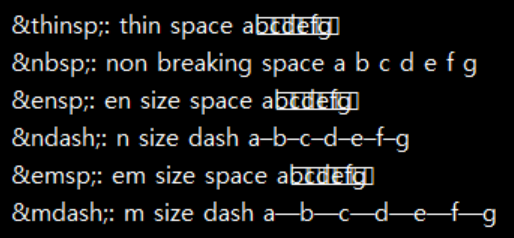

**Markdown spacing**

- Here package defaults at your working directory